# Exploratory Analysis

## Introduction

Throughout the pandemic, many of us experienced pain and familiarized ourselves to new type of lifestyle due to **COVID-19**. We have finally produced vaccinations, yet there are growing concerns to these vaccines. Thorough this project, we aim to:

1. Look through the data of *Covid-19 Vaccinations* and *COVID-19 Deaths* to see if there is any correlation between them.
2. We wish to find out about the *effectiveness of the COVID-19 vaccination*, and how it is differentiated throughout the *world*.
3. We aim to visualize through *effective graphs*, for us and our users to easily compare.

### Plot of Top 10 Countries with Highest Average Deaths

This plot shows the top 10 countries that had highest average deaths due to **COVID-19**. The data of countries have been visualized through bar graphs, with different colors to easily differentiate. In this graph, we are able to find out that **United States** had the highest average deaths, by nearly *600,000* deaths. Moreover, it is intriguing to find out that most of the countries that had highest deaths came from either *American continent*, or in the continent of *Europe*.

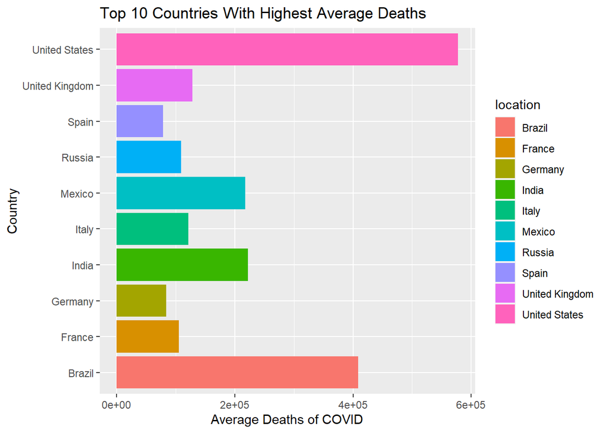

### Plot 2 of Distribution Variables

This plot shows the average number of vaccinations per month in the world. We can see that there is a positive trend, where the average number of vaccinations is increasing over time. In December 2020, the average number of vaccinations was *165381.6*, but it has increased to *19646193.2* vaccinations in May 2021. However, something that should be considered is that this trend may not be reflected when looking at different countries individually around the world. While this plot shows the overall average vaccination numbers for the world, different countries may show different numbers regarding the average number of vaccinations.

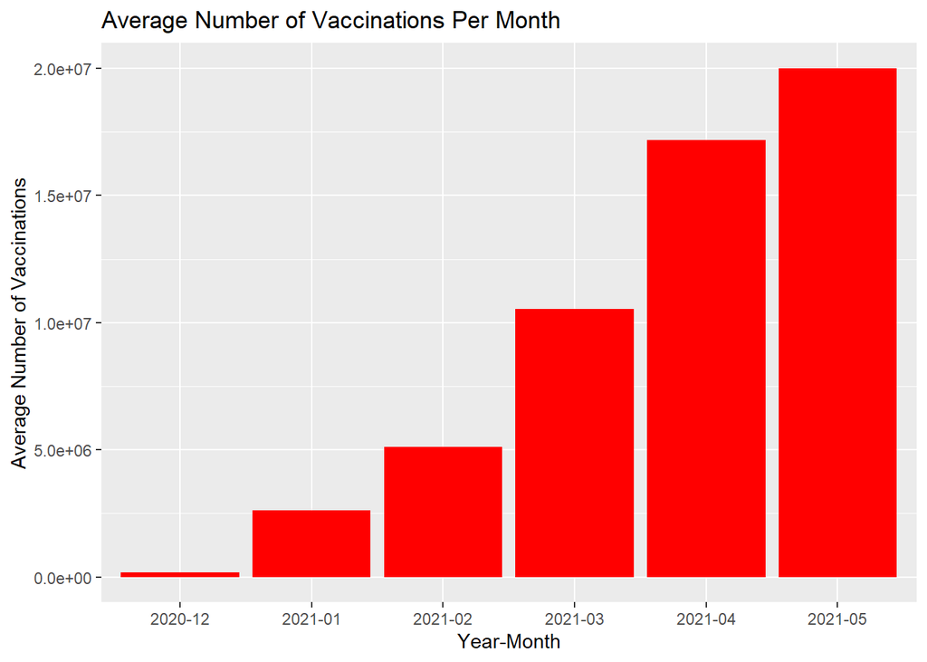